# 교통사고통계

권정환

2018년 10월 18일

# 활용 데이터

도로교통공단_전국_사망교통사고_2017.csv https://www.data.go.kr/dataset/15003493/fileData.do

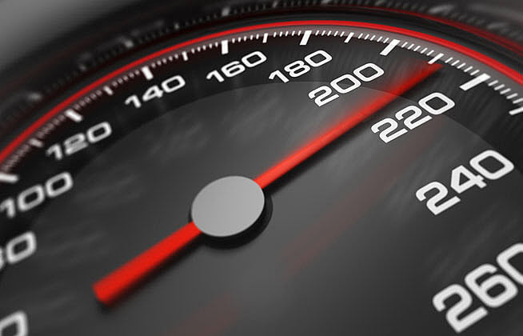

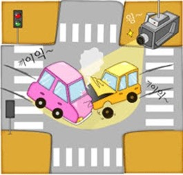

[figure not shown]

# 데이터 선정이유

-교통사고는 우리 주변에서 빈번하게 발생하고 있다. 친척과 친구 포함 주변인 중 꼭 몇 명은 교통사고로 목숨을 잃은 사람이 있을 정도로 매우 흔한 사망원인이다. 본인의 아주 친한 친구도 22세에 교통사고로 사망하였다. 본인도 어렸을 적 갤로퍼에 치여 수 미터를 날아간 적이 있고, 제대 후에는 운전을 하다가 차를 긁은 적이 있다. 아직도 트라우마로 남을 만큼 놀라고 두려운 경험이었다. 이후에는 운전을 하지 않아도 차에 탑승할 때 부모님 차나 택시, 심지어 버스를 탈 때에도 사고가 나면 어떡할까 걱정을 하곤 한다. 건널목을 지날 때에도 좌우를 유심히 살핀 후 건너는 버릇이 생겼다. 현대에는 자동차에 치이는 사고가 많다.

**2017년 기준 전국 승용차 등록대수: 약 1800만 대**

-이외에도 화물차, 승합차, 특수차량 등 전국에 등록된 모든 차량은 약 2200만 대

-교통사고는 더이상 우리 삶에서 멀리 떨어진 것이 아님 영화나 드라마 등에 빈번하게 등장하는 장면들이지만 현실에서도 매우 가까이 있는 위험 요소이기에 더욱 와닿는 장면들이다. 이러하여 본 발표에서는 여러 교통사고 중 2017년 전국 교통사망사고를 선정하여 분석해보고 교통사고에 대한 경각심을 일깨워보고자 한다.

# 분석 주제

*2017년의 전국 사망교통사고 통계를 이용해 월별, 지역별, 주야별 교통사고의 빈도를 비교해보고자 함

-지역별 비교의 경우 지도에 발생빈도를 시각화하고자 함(추후에)

# 데이터

| year | ymdh | minute | day_night | day | death | casualties | state | state2 | 사고유형_대분류 | 사고유형_중분류 | 사고유형 | 법규위반_대분류 | 법규위반 | 도로형태_대분류 | 도로형태 | 당사자종별_1당_대분류 | 당사자종별_1당 | 당사자종별_2당_대분류 | 당사자종별_2당 | 발생위치X_UTMK | 발생위치Y_UTMK | 경도 | 위도 |
| --- | --- | --- | --- | --- | --- | --- | --- | --- | --- | --- | --- | --- | --- | --- | --- | --- | --- | --- | --- | --- | --- | --- | --- |
| 2017 | 2017010104 | 0 | 야간 | 일 | 1 | 2 | 강원 | 춘천시 | 차대사람 | 횡단중 | 횡단중 | 운전자법규위반 | 안전운전 의무 불이행 | 단일로 | 기타단일로 | 승용차 | 승용차 | 보행자 | 보행자 | 1021195 | 1985798 | 127.740989 | 37.87175076 |
| 2017 | 2017010305 | 16 | 야간 | 화 | 1 | 1 | 강원 | 원주시 | 차대사람 | 횡단중 | 횡단중 | 운전자법규위반 | 보행자 보호의무 위반 | 교차로 | 교차로부근 | 승용차 | 승용차 | 보행자 | 보행자 | 1040515 | 1927745 | 127.95743812 | 37.34785241 |
| 2017 | 2017010520 | 55 | 야간 | 목 | 1 | 1 | 강원 | 양양군 | 차대사람 | 횡단중 | 횡단중 | 운전자법규위반 | 안전운전 의무 불이행 | 단일로 | 기타단일로 | 승용차 | 승용차 | 보행자 | 보행자 | 1097137 | 2017091 | 128.60889034 | 38.14880989 |
| 2017 | 2017010704 | 5 | 야간 | 토 | 1 | 1 | 강원 | 춘천시 | 차대사람 | 횡단중 | 횡단중 | 운전자법규위반 | 안전운전 의무 불이행 | 교차로 | 교차로내 | 승용차 | 승용차 | 보행자 | 보행자 | 1021038 | 1990363 | 127.73933707 | 37.91289869 |
| 2017 | 2017010918 | 20 | 야간 | 월 | 1 | 1 | 강원 | 속초시 | 차대차 | 추돌 | 추돌 | 운전자법규위반 | 안전운전 의무 불이행 | 기타 | 기타 | 승용차 | 승용차 | 자전거 | 자전거 | 1094333 | 2022190 | 128.57752075 | 38.19516442 |
| 2017 | 2017011021 | 50 | 야간 | 화 | 1 | 1 | 강원 | 인제군 | 차대차 | 정면충돌 | 정면충돌 | 운전자법규위반 | 안전운전 의무 불이행 | 단일로 | 기타단일로 | 승용차 | 승용차 | 화물차 | 화물차 | 1061296 | 2012080 | 128.19916433 | 38.10679463 |
| 2017 | 2017011318 | 5 | 야간 | 금 | 1 | 3 | 강원 | 평창군 | 차대사람 | 횡단중 | 횡단중 | 운전자법규위반 | 안전운전 의무 불이행 | 단일로 | 기타단일로 | 승용차 | 승용차 | 보행자 | 보행자 | 1079256 | 1930618 | 128.39511739 | 37.37124632 |
| 2017 | 2017011519 | 15 | 야간 | 일 | 1 | 4 | 강원 | 인제군 | 차대차 | 정면충돌 | 정면충돌 | 운전자법규위반 | 중앙선 침범 | 단일로 | 기타단일로 | 승용차 | 승용차 | 승합차 | 승합차 | 1063192 | 2014471 | 128.22100107 | 38.12821166 |

**지역별 발생빈도**

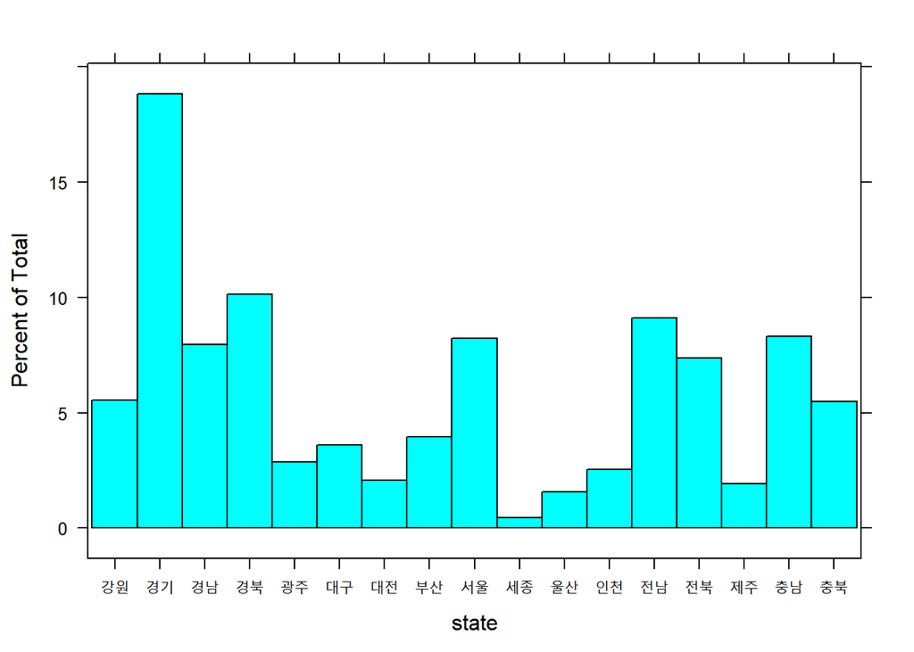

```r
library(lattice)
data01 <- read.csv("C://Users//gfdss//Desktop//datascience//homework1//MJU-2018-02-DataScience//도로교통공단_전국_사망교통사고_2017.csv")
histogram(casualties ~ state, data01)
```

# 주야별 발생빈도

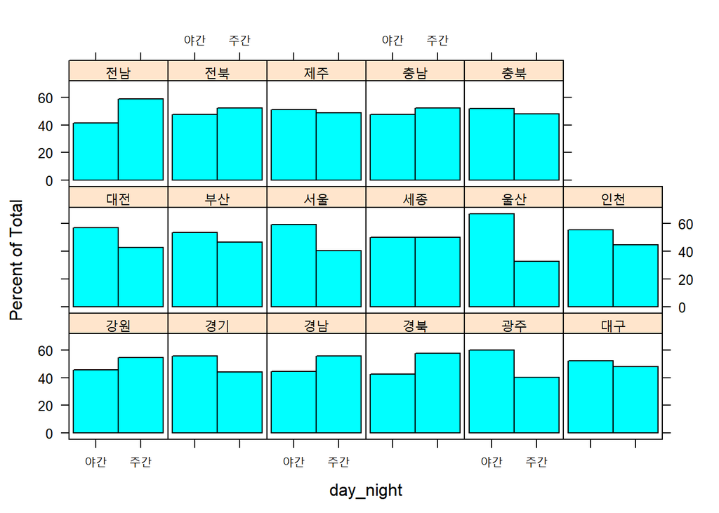

```r
library(lattice)
data01 <- read.csv("C://Users//gfdss//Desktop//datascience//homework1//MJU-2018-02-DataScience//도로교통공단_전국_사망교통사고_2017.csv")
histogram(casualties ~ day_night | state, data01)
```

# 월별 발생빈도

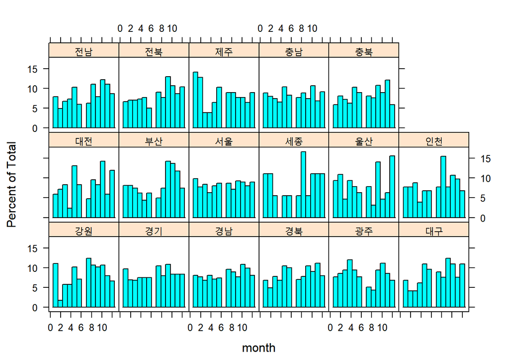

```r
library(lattice)
data01 <- read.csv("C://Users//gfdss//Desktop//datascience//homework1//MJU-2018-02-DataScience//도로교통공단_전국_사망교통사고_2017.csv")
histogram(casualties ~ month | state, data01)
```

# 마침

-상당히 많은 사람이 교통사고로 사망하고 있기에 이 주제를 분석해보는 우리나 발표를 듣는 학생 모두 운전을 할 때나 하지 않을 때나 각별히 주의해야겠다. 내가 아무리 잘해도 차가 와서 박아버리면 일어나는 것이 사고이기 때문에 교통사고는 시간과 장소를 가리지 않고 발생한다는 것을 잘 인지하고 평소에도 각별히 주의해야겠다. —